# K Nearest Neighbors

2025-11-03

## Introduction

The k-Nearest Neighbors algorithm is a method used for both classification and regression models. It works by finding the k data points in the training set that are closest to a new observation and making predictions based on their values. For classification tasks, the model assigns the most common class among the neighbors, while for regression it takes the average. Because k-NN relies on distance measures such as Euclidean or Manhattan distance, it’s important to scale the features beforehand. The algorithm is non-parametric, meaning it makes no assumptions about the underlying data distribution, and it can capture complex, non-linear relationships. However, it can become computationally expensive with large datasets and may perform poorly when irrelevant features or high-dimensional data are present. limitations.

I will develop several k-Nearest Neighbours (k-NN) models using the bankruptcy dataset to predict whether a company is likely to go bankrupt within the following year. I will begin by building a baseline model using the pre-processed data, which includes only variables from the current year of each observation. The model will then be tuned to optimise its predictive performance. Next, I will construct additional models that incorporate lag variables—features from previous years for the same company—to capture potential temporal patterns. Finally, I will evaluate all models and select the best-performing one based primarily on the Area Under the Curve (AUC) metric.

## Libraries

First the libraries need to be loaded in.

```r
library(caret)
library(dplyr)
library(pROC)
```

## Data

Before developing any models, data needs to be split into 4 different data sets - the base data set, in which each observation includes data for only that year; and n year lag data set in which each observation will include all the data from the base data set plus n years worth of previous data for that particular observation, where n is 1-3. for each of these there will be both a train and a test set.

Each of these train and test sets then needs to be split into a data frame that only includes the decision variables and a data frame which only includes the target variable.

The code below splits the data as described above.

```r
set.seed(123)

# import data sets to train with

val_train <- read.csv("https://raw.githubusercontent.com/railtonjamesl-collab/DataScienceFanClub/refs/heads/main/Data/Val_traindata/df_train_log_scaled_val.csv")
val_test <- read.csv("https://raw.githubusercontent.com/railtonjamesl-collab/DataScienceFanClub/refs/heads/main/Data/Val_traindata/df_test_log_scaled_val.csv")

# make sure target vars are factors

feature_lag0 = c('X1','X2','X3','X4','X5','X6','X7','X8','X9','X10','X11','X12','X13','X14','X15','X17','X18')
feature_lag1 = c(feature_lag0, 'X1_1yr','X2_1yr','X3_1yr','X4_1yr','X5_1yr','X6_1yr','X7_1yr','X8_1yr','X9_1yr','X10_1yr','X11_1yr','X12_1yr','X13_1yr','X14_1yr','X15_1yr','X17_1yr','X18_1yr')
feature_lag2 = c(feature_lag1, 'X1_2yr','X2_2yr','X3_2yr','X4_2yr','X5_2yr','X6_2yr','X7_2yr','X8_2yr','X9_2yr','X10_2yr','X11_2yr','X12_2yr','X13_2yr','X14_2yr','X15_2yr','X17_2yr','X18_2yr')
feature_lag3 = c(feature_lag2, 'X1_3yr','X2_3yr','X3_3yr','X4_3yr','X5_3yr','X6_3yr','X7_3yr','X8_3yr','X9_3yr','X10_3yr','X11_3yr','X12_3yr','X13_3yr','X14_3yr','X15_3yr','X17_3yr','X18_3yr')


## Base Data

x_train_base <-  val_train[, feature_lag0]
x_test_base <- val_test[, feature_lag0]

y_train_base <- factor(val_train[,'status_label_1yr'])
y_test_base <- factor(val_test[,'status_label_1yr'])

## Lag Data

# 1 year

x_train_lag1yr <- val_train[, feature_lag1]
x_test_lag1yr <- val_test[, feature_lag1]

y_train_lag1yr <- factor(val_train[, "status_label_1yr"])
y_test_lag1yr <- factor(val_test[, "status_label_1yr"])

# 2 years

x_train_lag2yr <- val_train[, feature_lag2]
x_test_lag2yr <- val_test[, feature_lag2]

y_train_lag2yr <- factor(val_train[, "status_label_1yr"])
y_test_lag2yr <- factor(val_test[, "status_label_1yr"])

# 3 years

x_train_lag3yr <- val_train[, feature_lag3]
x_test_lag3yr <- val_test[, feature_lag3]

y_train_lag3yr <- factor(val_train[, "status_label_1yr"])
y_test_lag3yr <- factor(val_test[, "status_label_1yr"])
```

## Basic Model

I will start by creating a basic model using the base data set. I have chosen to develop a model in which k is 5, there is no automatic cross validation (as this data is panel data and the in built function for this does not account for this), and no resampling. I will then test this data on the validation data set. The code for this is below.

```r
# Training KNN base model

ctr <- trainControl(method = "none",
                    sampling = NULL)

knnModel <- train(
  x = x_train_base,
  y = y_train_base,
  method = "knn",
  tuneGrid = data.frame(k = 5),
  trControl = ctr
)

print(knnModel)
```

```
## k-Nearest Neighbors
##
## 19063 samples
##    17 predictor
##     2 classes: 'alive', 'failed'
##
## No pre-processing
## Resampling: None
```

```r
# predict on test set for classification

pred_class <- predict(knnModel, newdata = x_test_base, type = "raw")
```

### Confusion Matrix

```r
conf_matrix <- confusionMatrix(pred_class, y_test_base)
print(conf_matrix)
```

```
## Confusion Matrix and Statistics
##
##           Reference
## Prediction alive failed
##     alive   1013      9
##     failed     1      0
##
##                Accuracy : 0.9902
##                  95% CI : (0.9821, 0.9953)
##     No Information Rate : 0.9912
##     P-Value [Acc > NIR] : 0.70651
##
##                   Kappa : -0.0018
##
##  Mcnemar's Test P-Value : 0.02686
##
##             Sensitivity : 0.9990
##             Specificity : 0.0000
##          Pos Pred Value : 0.9912
##          Neg Pred Value : 0.0000
##              Prevalence : 0.9912
##          Detection Rate : 0.9902
##    Detection Prevalence : 0.9990
##       Balanced Accuracy : 0.4995
##
##        'Positive' Class : alive
##
```

The above confusion matrix shows that there is only 1 “failed” prediction in the validation set from this model. This is due to the class imbalance in the status_label_1yr variable. This can be fixed by up-sampling or by using a synthetic over-sampling technique (SMOTE).

### ROC Curve and AUC

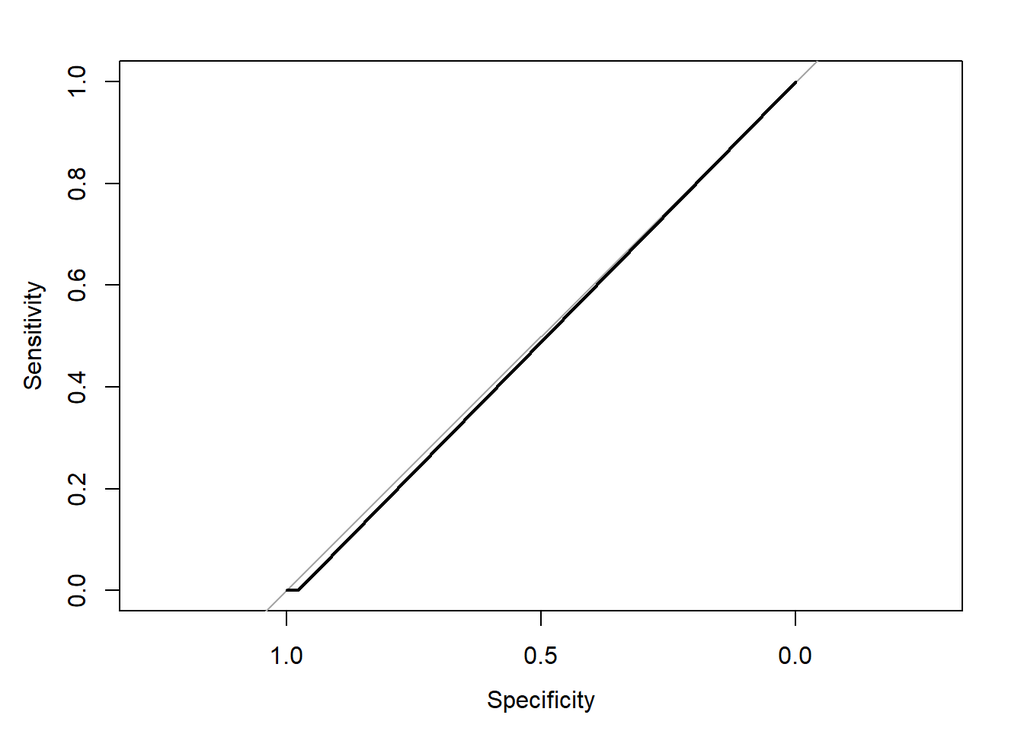

```r
# predict on test set for probabilities

pred_prob <- predict(knnModel, newdata = x_test_base, type = "prob")

# Roc curve
roc_obj <- roc(y_test_base, pred_prob[, "failed"])
plot(roc_obj)
```

```r
#  auc
auc_value <- auc(roc_obj)
print(auc_value)
```

```
## Area under the curve: 0.4887
```

From the above ROC curve and AUC value, it is clear that this model is not very accurate and does not effectively distinguish between different class values. This can be improved by increasing the value of K.

## Tuning K Nearest Neighbour Model

From the trivial model created in the previous section, it is clear that in order to tune and improve on this model, resampling needs to be performed and a variety of K values need to be tested. The below code is a function that allows a train and test data set to be passed aswell as a resampling method. Additionally, it tries all odd numbers for k from 1 to 51 then chooses the best model (based on AUC) out of these.

```r
knn_model <- function(train_x, train_y, test_x, test_y, resampling) {

  set.seed(123)

  # Use only odd K values (to avoid ties)
  k_values <- seq(1, 51, by = 2)

  # Control (no internal cross-validation)
  ctrl <- trainControl(
    method = "none",
    classProbs = TRUE,
    sampling = resampling
  )

  results <- data.frame(k = integer(), Accuracy = numeric(), AUC = numeric())
  models <- list()

  for (k in k_values) {

    # Train model
    knnModel <- train(
      x = train_x,
      y = train_y,
      method = "knn",
      tuneGrid = data.frame(k = k),
      trControl = ctrl
    )

    # Predictions (class)
    pred_class <- predict(knnModel, newdata = test_x, type = "raw")
    conf <- confusionMatrix(pred_class, test_y)

    # Predictions (probabilities)
    pred_prob <- predict(knnModel, newdata = test_x, type = "prob")

    # ROC + AUC
    roc_obj <- tryCatch({
      roc(test_y, pred_prob[, "failed"], quiet = TRUE)
    }, error = function(e) NA)

    auc_val <- if (!is.na(roc_obj)[1]) auc(roc_obj) else NA

    # Store performance
    results <- rbind(results, data.frame(
      k = k,
      Accuracy = conf$overall["Accuracy"],
      AUC = auc_val
    ))

    # Store model info
    models[[paste0("k_", k)]] <- list(
      model = knnModel,
      conf = conf,
      roc = roc_obj,
      auc = auc_val
    )
  }

  # Find best model (prioritize AUC, fallback to Accuracy if AUC missing)
  if (all(is.na(results$AUC))) {
    best_k <- results$k[which.max(results$Accuracy)]
    metric_used <- "Accuracy"
  } else {
    best_k <- results$k[which.max(results$AUC)]
    metric_used <- "AUC"
  }

  best_model <- models[[paste0("k_", best_k)]]

  # Summary printout
  message(paste0("✅ Best K = ", best_k, " (based on ", metric_used, ")"))
  message(paste0("   Accuracy: ", round(best_model$conf$overall["Accuracy"], 4)))
  if (!is.na(best_model$auc)) message(paste0("   AUC: ", round(best_model$auc, 4)))

  # Return everything
  return(list(
    k = best_k,
    model = best_model$model,
    conf_matrix = best_model$conf,
    roc = best_model$roc,
    auc = best_model$auc,
    all_results = results,
    all_models = models
  ))
}
```

## Base Model

Starting with the base data, I will run the above function with no resampling, up-sampling and smoting.

```r
knn_basic <- knn_model(x_train_base, y_train_base, x_test_base, y_test_base, NULL)
```

```
## ✅ Best K = 49 (based on AUC)
```

```
##    Accuracy: 0.9912
```

```
##    AUC: 0.8293
```

```r
knn_us <- knn_model(x_train_base, y_train_base, x_test_base, y_test_base, "up")
```

```
## ✅ Best K = 49 (based on AUC)
```

```
##    Accuracy: 0.8495
```

```
##    AUC: 0.82
```

```r
knn_smote <- knn_model(x_train_base, y_train_base, x_test_base, y_test_base, "smote")
```

```
## ✅ Best K = 27 (based on AUC)
```

```
##    Accuracy: 0.8974
```

```
##    AUC: 0.8694
```

### Confusion Matrix

Below are the confusion matrices for all three of these models.

```r
message("confusion matrix for no resampling model: ")
```

```
## confusion matrix for no resampling model:
```

```r
print(knn_basic$conf_matrix)
```

```
## Confusion Matrix and Statistics
##
##           Reference
## Prediction alive failed
##     alive   1014      9
##     failed     0      0
##
##                Accuracy : 0.9912
##                  95% CI : (0.9834, 0.996)
##     No Information Rate : 0.9912
##     P-Value [Acc > NIR] : 0.587409
##
##                   Kappa : 0
##
##  Mcnemar's Test P-Value : 0.007661
##
##             Sensitivity : 1.0000
##             Specificity : 0.0000
##          Pos Pred Value : 0.9912
##          Neg Pred Value :    NaN
##              Prevalence : 0.9912
##          Detection Rate : 0.9912
##    Detection Prevalence : 1.0000
##       Balanced Accuracy : 0.5000
##
##        'Positive' Class : alive
##
```

```r
message("confusion matrix for up-sampling model: ")
```

```
## confusion matrix for up-sampling model:
```

```r
print(knn_us$conf_matrix)
```

```
## Confusion Matrix and Statistics
##
##           Reference
## Prediction alive failed
##     alive    862      2
##     failed   152      7
##
##                Accuracy : 0.8495
##                  95% CI : (0.8261, 0.8708)
##     No Information Rate : 0.9912
##     P-Value [Acc > NIR] : 1
##
##                   Kappa : 0.0678
##
##  Mcnemar's Test P-Value : <2e-16
##
##             Sensitivity : 0.85010
##             Specificity : 0.77778
##          Pos Pred Value : 0.99769
##          Neg Pred Value : 0.04403
##              Prevalence : 0.99120
##          Detection Rate : 0.84262
##    Detection Prevalence : 0.84457
##       Balanced Accuracy : 0.81394
##
##        'Positive' Class : alive
##
```

```r
message("confusion matrix for smote model: ")
```

```
## confusion matrix for smote model:
```

```r
print(knn_smote$conf_matrix)
```

```
## Confusion Matrix and Statistics
##
##           Reference
## Prediction alive failed
##     alive    911      2
##     failed   103      7
##
##                Accuracy : 0.8974
##                  95% CI : (0.8771, 0.9153)
##     No Information Rate : 0.9912
##     P-Value [Acc > NIR] : 1
##
##                   Kappa : 0.1031
##
##  Mcnemar's Test P-Value : <2e-16
##
##             Sensitivity : 0.89842
##             Specificity : 0.77778
##          Pos Pred Value : 0.99781
##          Neg Pred Value : 0.06364
##              Prevalence : 0.99120
##          Detection Rate : 0.89052
##    Detection Prevalence : 0.89247
##       Balanced Accuracy : 0.83810
##
##        'Positive' Class : alive
##
```

From this it can be seen again that there is a class imbalance leading to no failed prediction in the model without any resampling.

### Visualisation of ROC Curve and AUC Value

```r
plot(knn_basic$roc)
title(main = "No Resampling")

plot(knn_us$roc)
title(main = "Up-sampling")

plot(knn_smote$roc)
title(main = "Smoting")

message(paste0("AUC for model with no resampling: ",knn_basic$auc))
```

```
## AUC for model with no resampling: 0.829278983125137
```

```r
message(paste0("AUC for model with up-sampling: ", knn_us$auc))
```

```
## AUC for model with up-sampling: 0.820019723865878
```

```r
message(paste0("AUC for model with smoting: ", knn_smote$auc))
```

```
## AUC for model with smoting: 0.869438965592812
```

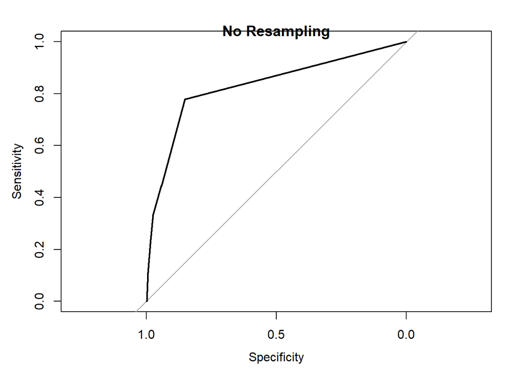

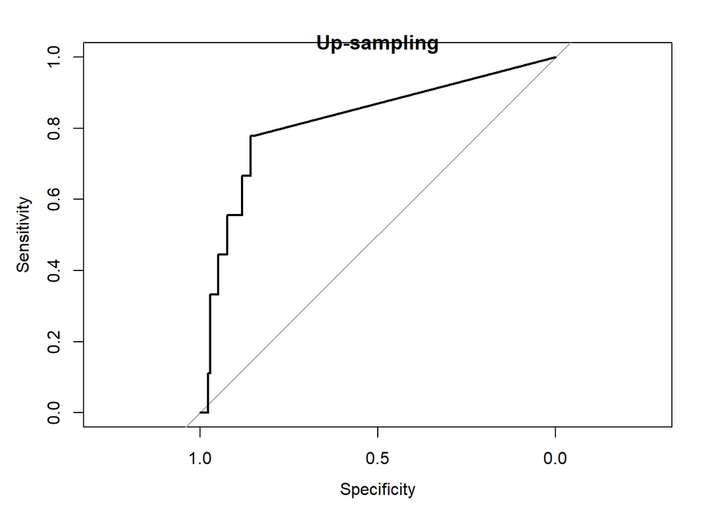

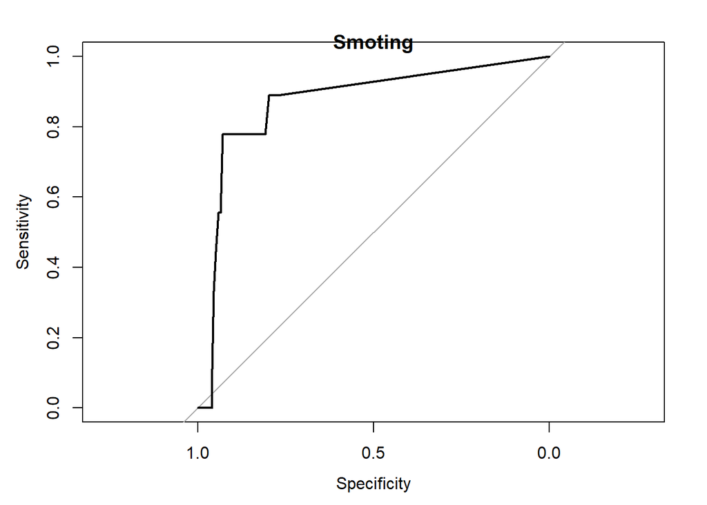

This shows that the model that uses smoting has the best ROC curve and AUC Value, followed by the model without resampling and then the up-sampling model.

### Conclusion

For the base data, I will conclude that the best model is the smote model as this has the best AUC value. The details of this model are below,

```r
message(paste0("K = ", knn_smote$k))
```

```
## K = 27
```

```r
message("Confusion Matrix: ")
```

```
## Confusion Matrix:
```

```r
print(knn_smote$conf_matrix$table)
```

```
##           Reference
## Prediction alive failed
##     alive    911      2
##     failed   103      7
```

```r
message("ROC Curve: ")
```

```
## ROC Curve:
```

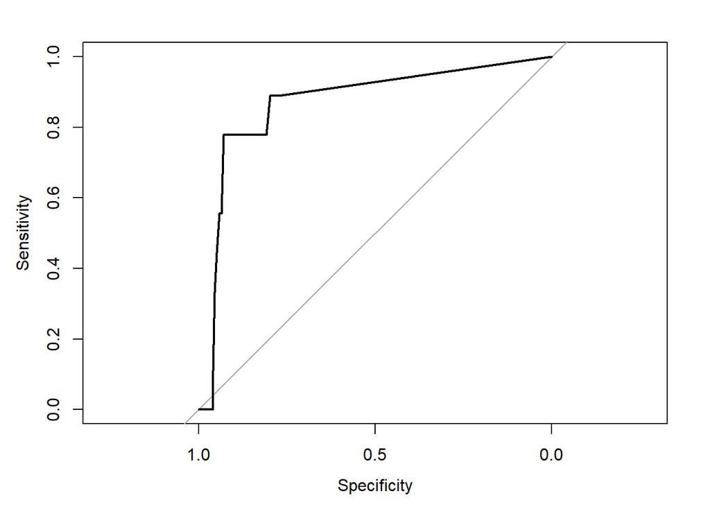

```r
plot(knn_smote$roc)
```

```r
message(paste0("AUC: ", knn_smote$auc ))
```

```
## AUC: 0.869438965592812
```

```r
message("Other performance metrics: ")
```

```
## Other performance metrics:
```

```r
print(knn_smote$conf_matrix$overall)
```

```
##       Accuracy          Kappa  AccuracyLower  AccuracyUpper   AccuracyNull
##   8.973607e-01   1.030587e-01   8.771166e-01   9.152824e-01   9.912023e-01
## AccuracyPValue  McnemarPValue
##   1.000000e+00   1.688103e-22
```

```r
print(knn_smote$conf_matrix$byClass)
```

```
##          Sensitivity          Specificity       Pos Pred Value
##           0.89842209           0.77777778           0.99780942
##       Neg Pred Value            Precision               Recall
##           0.06363636           0.99780942           0.89842209
##                   F1           Prevalence       Detection Rate
##           0.94551116           0.99120235           0.89051808
## Detection Prevalence    Balanced Accuracy
##           0.89247312           0.83809993
```

## 1 Year Lag Model

I will now create the same models with the 1 year lag data.

```r
knn_basic_1yr <- knn_model(x_train_lag1yr, y_train_lag1yr, x_test_lag1yr, y_test_lag1yr, NULL)
```

```
## ✅ Best K = 51 (based on AUC)
```

```
##    Accuracy: 0.9912
```

```
##    AUC: 0.8202
```

```r
knn_us_1yr <- knn_model(x_train_lag1yr, y_train_lag1yr, x_test_lag1yr, y_test_lag1yr, "up")
```

```
## ✅ Best K = 45 (based on AUC)
```

```
##    Accuracy: 0.8543
```

```
##    AUC: 0.818
```

```r
knn_smote_1yr <- knn_model(x_train_lag1yr, y_train_lag1yr, x_test_lag1yr, y_test_lag1yr, "smote")
```

```
## ✅ Best K = 25 (based on AUC)
```

```
##    Accuracy: 0.8886
```

```
##    AUC: 0.8556
```

### Confusion Matrix

Below are the confusion matrices for all three of these models.

```r
message("confusion matrix for no resampling model: ")
```

```
## confusion matrix for no resampling model:
```

```r
print(knn_basic_1yr$conf_matrix)
```

```
## Confusion Matrix and Statistics
##
##           Reference
## Prediction alive failed
##     alive   1014      9
##     failed     0      0
##
##                Accuracy : 0.9912
##                  95% CI : (0.9834, 0.996)
##     No Information Rate : 0.9912
##     P-Value [Acc > NIR] : 0.587409
##
##                   Kappa : 0
##
##  Mcnemar's Test P-Value : 0.007661
##
##             Sensitivity : 1.0000
##             Specificity : 0.0000
##          Pos Pred Value : 0.9912
##          Neg Pred Value :    NaN
##              Prevalence : 0.9912
##          Detection Rate : 0.9912
##    Detection Prevalence : 1.0000
##       Balanced Accuracy : 0.5000
##
##        'Positive' Class : alive
##
```

```r
message("confusion matrix for up-sampling model: ")
```

```
## confusion matrix for up-sampling model:
```

```r
print(knn_us_1yr$conf_matrix)
```

```
## Confusion Matrix and Statistics
##
##           Reference
## Prediction alive failed
##     alive    867      2
##     failed   147      7
##
##                Accuracy : 0.8543
##                  95% CI : (0.8312, 0.8754)
##     No Information Rate : 0.9912
##     P-Value [Acc > NIR] : 1
##
##                   Kappa : 0.0704
##
##  Mcnemar's Test P-Value : <2e-16
##
##             Sensitivity : 0.85503
##             Specificity : 0.77778
##          Pos Pred Value : 0.99770
##          Neg Pred Value : 0.04545
##              Prevalence : 0.99120
##          Detection Rate : 0.84751
##    Detection Prevalence : 0.84946
##       Balanced Accuracy : 0.81640
##
##        'Positive' Class : alive
##
```

```r
message("confusion matrix for smote model: ")
```

```
## confusion matrix for smote model:
```

```r
print(knn_smote_1yr$conf_matrix)
```

```
## Confusion Matrix and Statistics
##
##           Reference
## Prediction alive failed
##     alive    904      4
##     failed   110      5
##
##                Accuracy : 0.8886
##                  95% CI : (0.8677, 0.9072)
##     No Information Rate : 0.9912
##     P-Value [Acc > NIR] : 1
##
##                   Kappa : 0.0654
##
##  Mcnemar's Test P-Value : <2e-16
##
##             Sensitivity : 0.89152
##             Specificity : 0.55556
##          Pos Pred Value : 0.99559
##          Neg Pred Value : 0.04348
##              Prevalence : 0.99120
##          Detection Rate : 0.88368
##    Detection Prevalence : 0.88759
##       Balanced Accuracy : 0.72354
##
##        'Positive' Class : alive
##
```

From this it can be seen again that there is a class imbalance leading to no failed prediction in the model without any resampling.

### Visualisation of ROC Curve and AUC Value

```r
plot(knn_basic_1yr$roc)
title(main = "No Resampling")

plot(knn_us_1yr$roc)
title(main = "Up-sampling")

plot(knn_smote_1yr$roc)
title(main = "Smoting")

message(paste0("AUC for model with no resampling: ",knn_basic_1yr$auc))
```

```
## AUC for model with no resampling: 0.820238877931186
```

```r
message(paste0("AUC for model with up-sampling: ", knn_us_1yr$auc))
```

```
## AUC for model with up-sampling: 0.81799254876178
```

```r
message(paste0("AUC for model with smoting: ", knn_smote_1yr$auc))
```

```
## AUC for model with smoting: 0.855632259478413
```

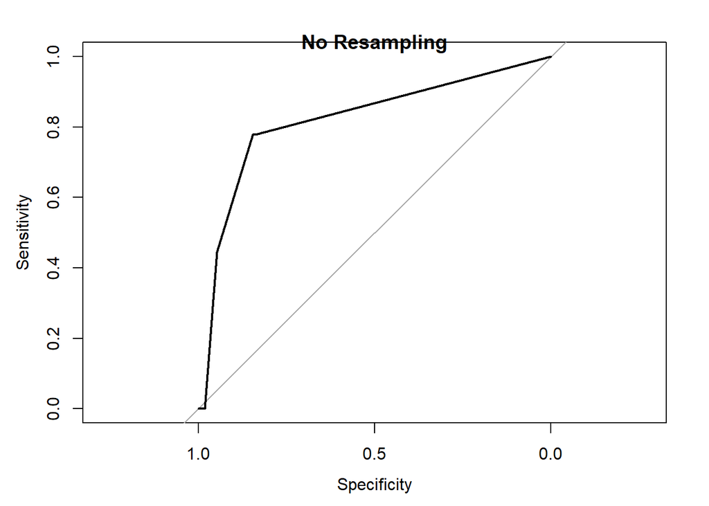

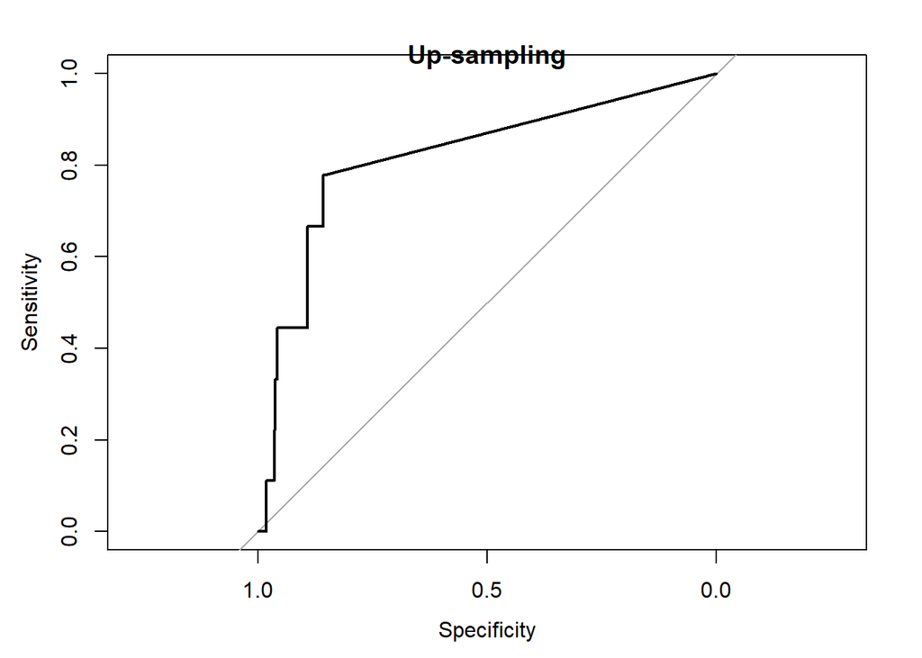

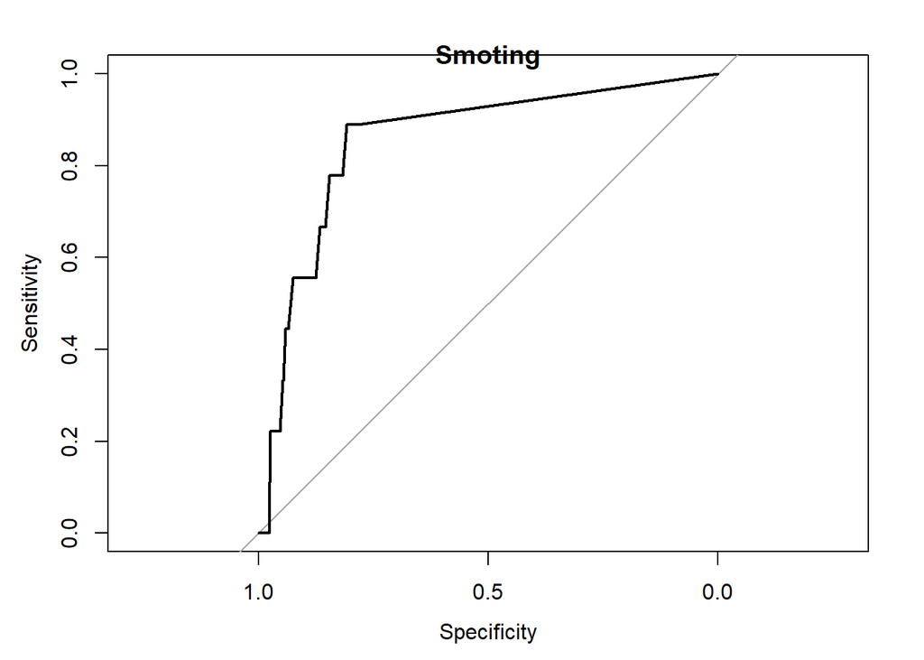

This shows that the model that uses smoting has the best ROC curve and AUC.

### Conclusion

For the 1 year lag data, I will conclude that the best model is the smote model as it has the best AUC value. The details of this model are below,

```r
message(paste0("K = ", knn_smote_1yr$k))
```

```
## K = 25
```

```r
message("Confusion Matrix: ")
```

```
## Confusion Matrix:
```

```r
print(knn_smote_1yr$conf_matrix$table)
```

```
##           Reference
## Prediction alive failed
##     alive    904      4
##     failed   110      5
```

```r
message("ROC Curve: ")
```

```
## ROC Curve:
```

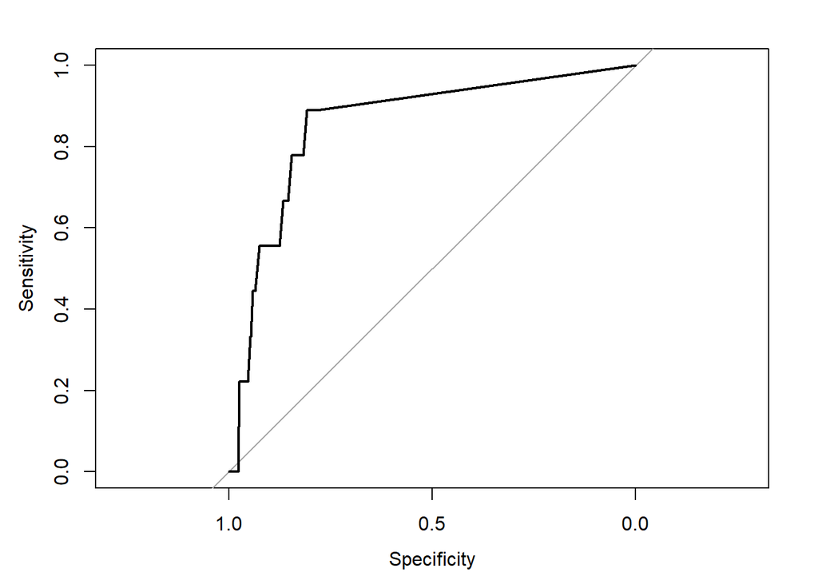

```r
plot(knn_smote_1yr$roc)
```

```r
message(paste0("AUC: ", knn_smote_1yr$auc ))
```

```
## AUC: 0.855632259478413
```

```r
message("Other performance metrics: ")
```

```
## Other performance metrics:
```

```r
print(knn_smote_1yr$conf_matrix$overall)
```

```
##       Accuracy          Kappa  AccuracyLower  AccuracyUpper   AccuracyNull
##   8.885630e-01   6.539405e-02   8.676630e-01   9.071948e-01   9.912023e-01
## AccuracyPValue  McnemarPValue
##   1.000000e+00   8.024152e-23
```

```r
print(knn_smote_1yr$conf_matrix$byClass)
```

```
##          Sensitivity          Specificity       Pos Pred Value
##           0.89151874           0.55555556           0.99559471
##       Neg Pred Value            Precision               Recall
##           0.04347826           0.99559471           0.89151874
##                   F1           Prevalence       Detection Rate
##           0.94068678           0.99120235           0.88367546
## Detection Prevalence    Balanced Accuracy
##           0.88758553           0.72353715
```

## 2 Year Lag Model

I will now create the same models with the 2 year lag data.

```r
knn_basic_2yr <- knn_model(x_train_lag2yr, y_train_lag2yr, x_test_lag2yr, y_test_lag2yr, NULL)
```

```
## ✅ Best K = 37 (based on AUC)
```

```
##    Accuracy: 0.9912
```

```
##    AUC: 0.9005
```

```r
knn_us_2yr <- knn_model(x_train_lag2yr, y_train_lag2yr, x_test_lag2yr, y_test_lag2yr, "up")
```

```
## ✅ Best K = 47 (based on AUC)
```

```
##    Accuracy: 0.8387
```

```
##    AUC: 0.8818
```

```r
knn_smote_2yr <- knn_model(x_train_lag2yr, y_train_lag2yr, x_test_lag2yr, y_test_lag2yr, "smote")
```

```
## ✅ Best K = 31 (based on AUC)
```

```
##    Accuracy: 0.868
```

```
##    AUC: 0.8734
```

### Confusion Matrix

Below are the confusion matrices for all three of these models.

```r
message("confusion matrix for no resampling model: ")
```

```
## confusion matrix for no resampling model:
```

```r
print(knn_basic_2yr$conf_matrix)
```

```
## Confusion Matrix and Statistics
##
##           Reference
## Prediction alive failed
##     alive   1014      9
##     failed     0      0
##
##                Accuracy : 0.9912
##                  95% CI : (0.9834, 0.996)
##     No Information Rate : 0.9912
##     P-Value [Acc > NIR] : 0.587409
##
##                   Kappa : 0
##
##  Mcnemar's Test P-Value : 0.007661
##
##             Sensitivity : 1.0000
##             Specificity : 0.0000
##          Pos Pred Value : 0.9912
##          Neg Pred Value :    NaN
##              Prevalence : 0.9912
##          Detection Rate : 0.9912
##    Detection Prevalence : 1.0000
##       Balanced Accuracy : 0.5000
##
##        'Positive' Class : alive
##
```

```r
message("confusion matrix for up-sampling model: ")
```

```
## confusion matrix for up-sampling model:
```

```r
print(knn_us_2yr$conf_matrix)
```

```
## Confusion Matrix and Statistics
##
##           Reference
## Prediction alive failed
##     alive    850      1
##     failed   164      8
##
##                Accuracy : 0.8387
##                  95% CI : (0.8147, 0.8607)
##     No Information Rate : 0.9912
##     P-Value [Acc > NIR] : 1
##
##                   Kappa : 0.0729
##
##  Mcnemar's Test P-Value : <2e-16
##
##             Sensitivity : 0.83826
##             Specificity : 0.88889
##          Pos Pred Value : 0.99882
##          Neg Pred Value : 0.04651
##              Prevalence : 0.99120
##          Detection Rate : 0.83089
##    Detection Prevalence : 0.83187
##       Balanced Accuracy : 0.86358
##
##        'Positive' Class : alive
##
```

```r
message("confusion matrix for smote model: ")
```

```
## confusion matrix for smote model:
```

```r
print(knn_smote_2yr$conf_matrix)
```

```
## Confusion Matrix and Statistics
##
##           Reference
## Prediction alive failed
##     alive    881      2
##     failed   133      7
##
##                Accuracy : 0.868
##                  95% CI : (0.8457, 0.8882)
##     No Information Rate : 0.9912
##     P-Value [Acc > NIR] : 1
##
##                   Kappa : 0.0787
##
##  Mcnemar's Test P-Value : <2e-16
##
##             Sensitivity : 0.8688
##             Specificity : 0.7778
##          Pos Pred Value : 0.9977
##          Neg Pred Value : 0.0500
##              Prevalence : 0.9912
##          Detection Rate : 0.8612
##    Detection Prevalence : 0.8631
##       Balanced Accuracy : 0.8233
##
##        'Positive' Class : alive
##
```

From this it can be seen again that there is a class imbalance leading to no failed prediction in the model without any resampling.

### Visualisation of ROC Curve and AUC Value

```r
plot(knn_basic_2yr$roc)
title(main = "No Resampling")

plot(knn_us_2yr$roc)
title(main = "Up-sampling")

plot(knn_smote_2yr$roc)
title(main = "Smoting")

message(paste0("AUC for model with no resampling: ",knn_basic_2yr$auc))
```

```
## AUC for model with no resampling: 0.900504054350208
```

```r
message(paste0("AUC for model with up-sampling: ", knn_us_2yr$auc))
```

```
## AUC for model with up-sampling: 0.881766381766382
```

```r
message(paste0("AUC for model with smoting: ", knn_smote_2yr$auc))
```

```
## AUC for model with smoting: 0.873383738768354
```

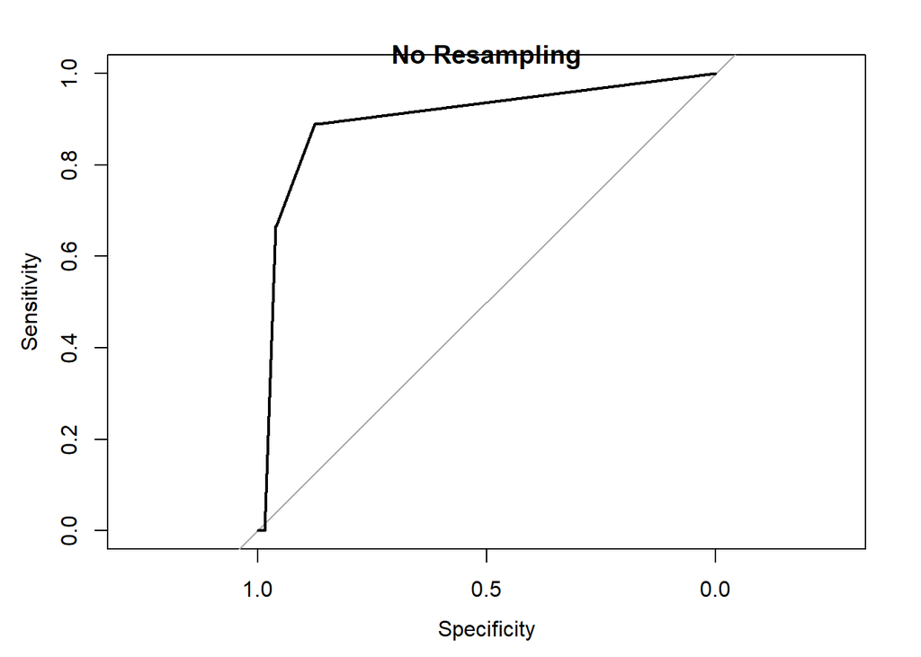

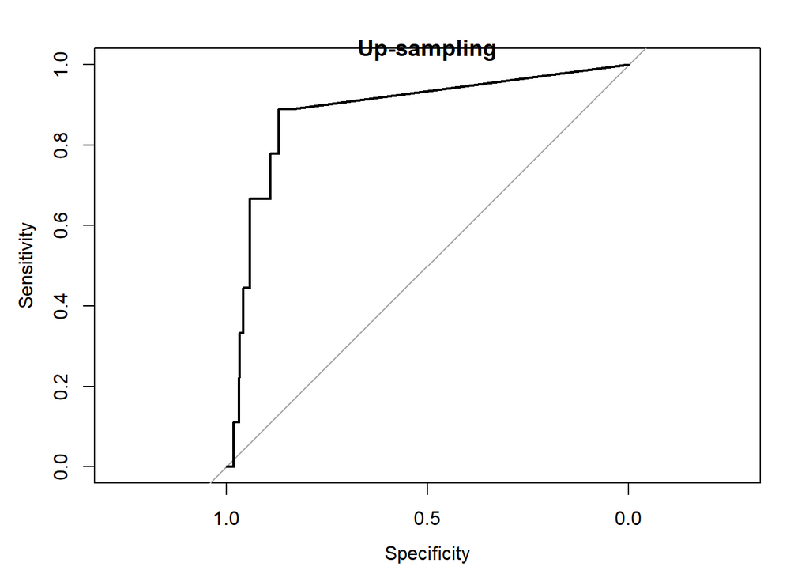

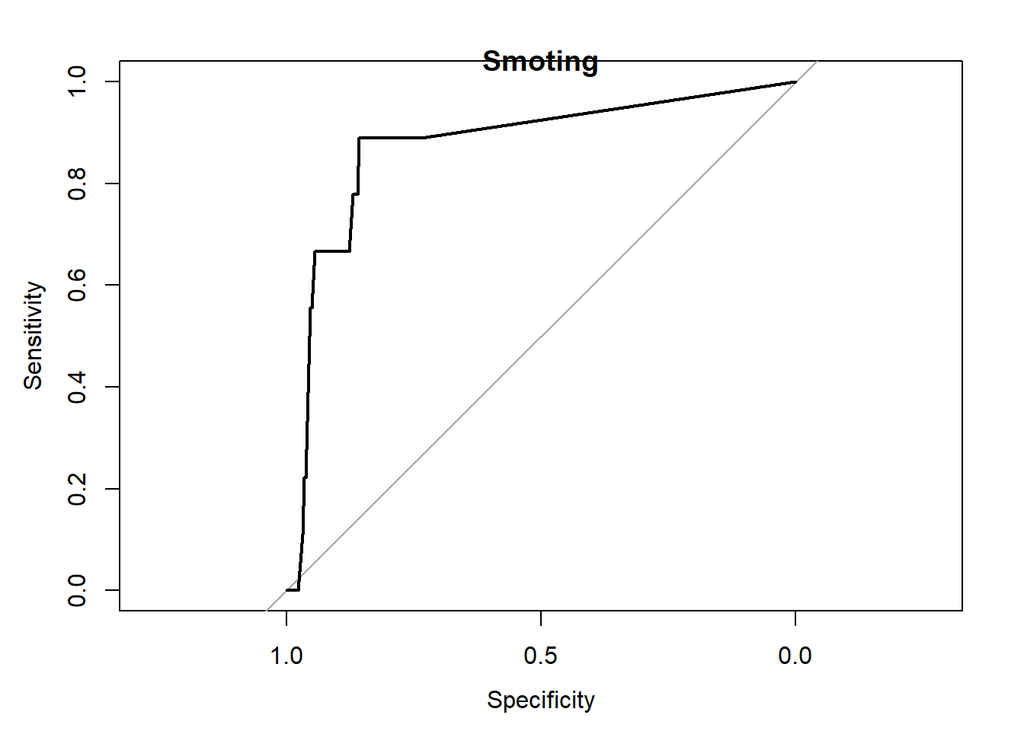

This shows that the model without resampling has the best ROC curve and AUC Value, closely followed by the up-sampling model and then the smote model.

### Conclusion

For the 2 year lag data, I will conclude that the best model is the up-sampling model as, although this only has the second best AUC, it does still predict failed companies whereas the model without resampling does not. The details of this model are below,

```r
message(paste0("K = ", knn_us_2yr$k))
```

```
## K = 47
```

```r
message("Confusion Matrix: ")
```

```
## Confusion Matrix:
```

```r
print(knn_us_2yr$conf_matrix$table)
```

```
##           Reference
## Prediction alive failed
##     alive    850      1
##     failed   164      8
```

```r
message("ROC Curve: ")
```

```
## ROC Curve:
```

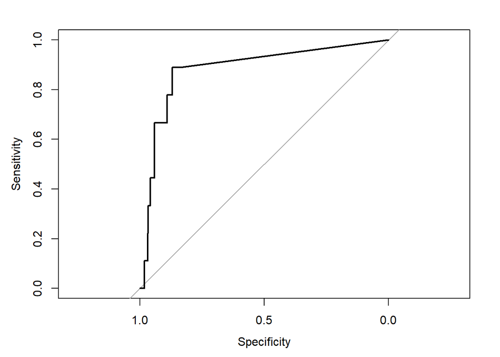

```r
plot(knn_us_2yr$roc)
```

```r
message(paste0("AUC: ", knn_us_2yr$auc ))
```

```
## AUC: 0.881766381766382
```

```r
message("Other performance metrics: ")
```

```
## Other performance metrics:
```

```r
print(knn_us_2yr$conf_matrix$overall)
```

```
##       Accuracy          Kappa  AccuracyLower  AccuracyUpper   AccuracyNull
##   8.387097e-01   7.289624e-02   8.147145e-01   8.607366e-01   9.912023e-01
## AccuracyPValue  McnemarPValue
##   1.000000e+00   1.820633e-36
```

```r
print(knn_us_2yr$conf_matrix$byClass)
```

```
##          Sensitivity          Specificity       Pos Pred Value
##           0.83826430           0.88888889           0.99882491
##       Neg Pred Value            Precision               Recall
##           0.04651163           0.99882491           0.83826430
##                   F1           Prevalence       Detection Rate
##           0.91152815           0.99120235           0.83088954
## Detection Prevalence    Balanced Accuracy
##           0.83186706           0.86357659
```

## 3 Year Lag Model

When attempting to run the function on the data set with 3 years of lag features, it is to computationally intense to run due to the number of variables. Given that the AUC values for all other data sets do not provide that much of a varying AUC value, it is not worth the time it may take to run this for a marginally higher AUC value.

### Evaluating the Best Model

The the best model for each data set was the smote model for the base data and the 1 year lag data, and the up-sampling model for the two year data. Below are the ROC curves for these. Below are the ROC curves for these models:

```r
plot(knn_smote$roc)
title(main = "Smote Model - Base Data")

plot(knn_smote_1yr$roc)
title(main = "Smote Model - 1 Year lag Data")

plot(knn_us_2yr$roc)
title(main = "Up-sampling Model - 2 Year Lag Data")

message(paste0("The AUC for the best base model is: ", knn_smote$auc))
```

```
## The AUC for the best base model is: 0.869438965592812
```

```r
message(paste0("The AUC for the best 1 year lag model is: ", knn_smote_1yr$auc))
```

```
## The AUC for the best 1 year lag model is: 0.855632259478413
```

```r
message(paste0("The AUC for the best 2 year lag model is: ", knn_us_2yr$auc))
```

```
## The AUC for the best 2 year lag model is: 0.881766381766382
```

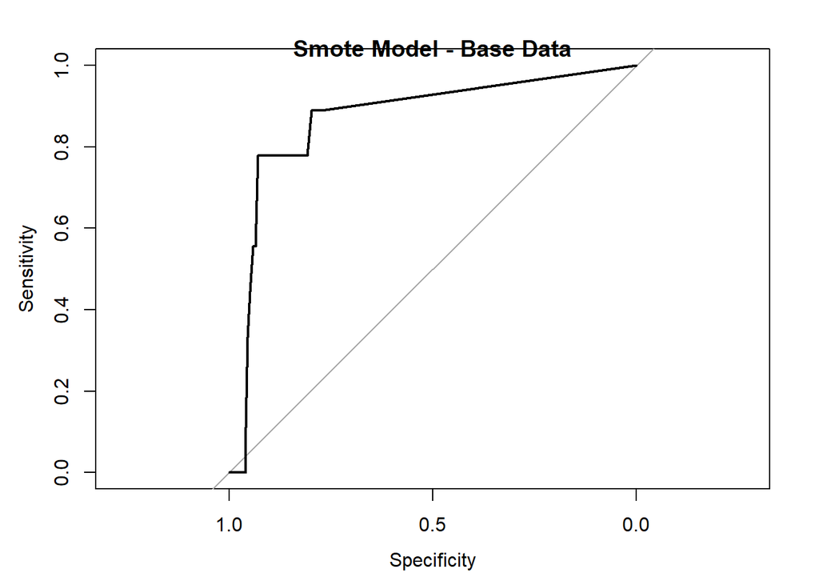

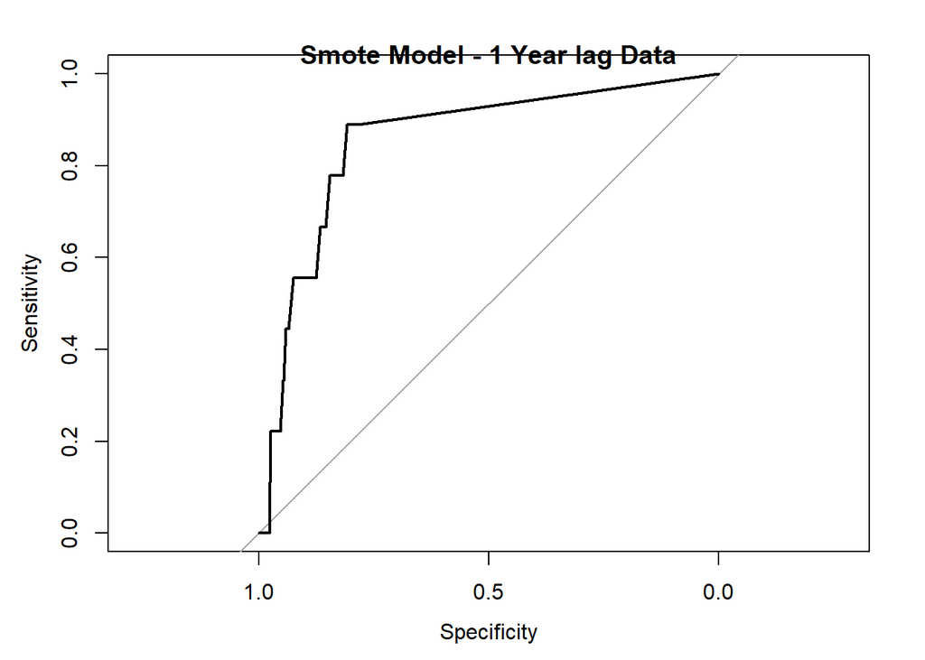

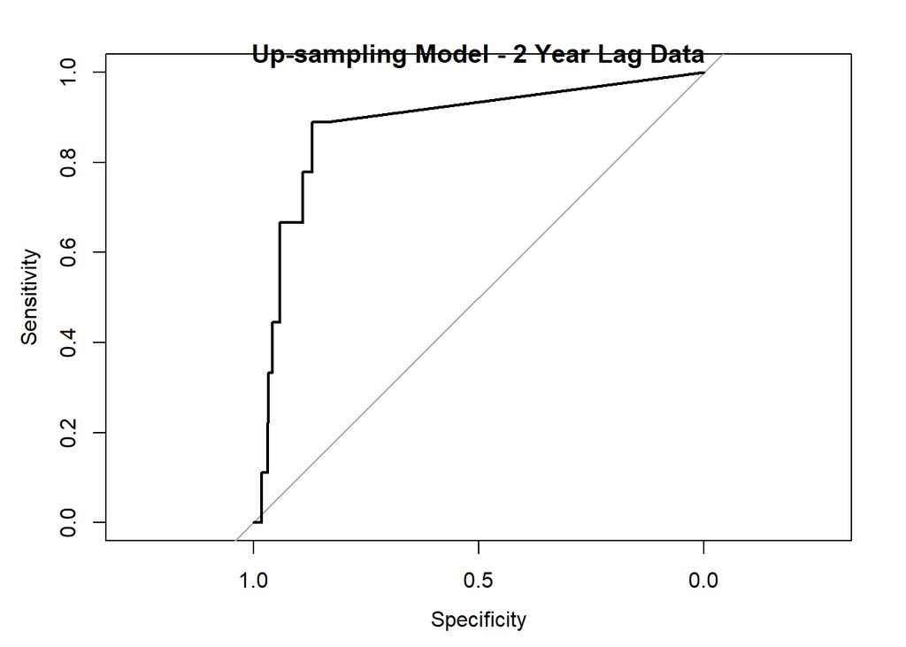

From this, it is clear to see that when prioritising a high AUC, the 2 year lag model, with up-sampling is the best model. The details for this model are below.

```r
message(paste0("K = ", knn_us_2yr$k))
```

```
## K = 47
```

```r
message("Confusion Matrix: ")
```

```
## Confusion Matrix:
```

```r
print(knn_us_2yr$conf_matrix$table)
```

```
##           Reference
## Prediction alive failed
##     alive    850      1
##     failed   164      8
```

```r
message("ROC Curve: ")
```

```
## ROC Curve:
```

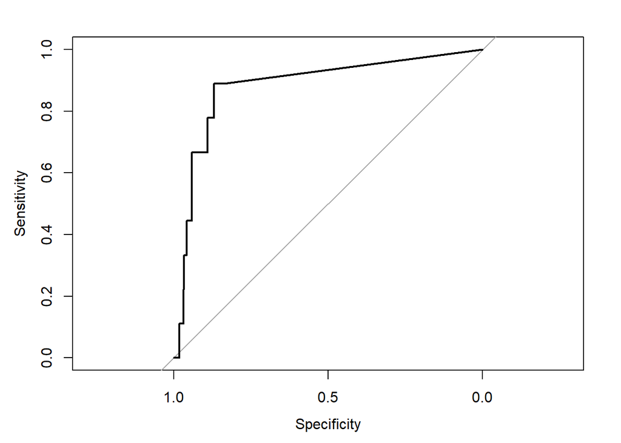

```r
plot(knn_us_2yr$roc)
```

```r
message(paste0("AUC: ", knn_us_2yr$auc ))
```

```
## AUC: 0.881766381766382
```

```r
message("Other performance metrics: ")
```

```
## Other performance metrics:
```

```r
print(knn_us_2yr$conf_matrix$overall)
```

```
##       Accuracy          Kappa  AccuracyLower  AccuracyUpper   AccuracyNull
##   8.387097e-01   7.289624e-02   8.147145e-01   8.607366e-01   9.912023e-01
## AccuracyPValue  McnemarPValue
##   1.000000e+00   1.820633e-36
```

```r
print(knn_us_2yr$conf_matrix$byClass)
```

```
##          Sensitivity          Specificity       Pos Pred Value
##           0.83826430           0.88888889           0.99882491
##       Neg Pred Value            Precision               Recall
##           0.04651163           0.99882491           0.83826430
##                   F1           Prevalence       Detection Rate
##           0.91152815           0.99120235           0.83088954
## Detection Prevalence    Balanced Accuracy
##           0.83186706           0.86357659
```

### Final Model Development

```r
final_train <- read.csv("~/University of Bristol/Semester 1/Data Science Toolbox/Assessments/Assessment 1/DataScienceFanClub/Data/Final_traindata/df_train_log_scaled_full.csv")
final_test <- read.csv("~/University of Bristol/Semester 1/Data Science Toolbox/Assessments/Assessment 1/DataScienceFanClub/Data/Final_traindata/df_test_log_scaled.csv")

x_train_lag2yr_full <- final_train[, feature_lag2]
x_test_lag2yr_full <- final_test[, feature_lag2]

y_train_lag2yr_full <- factor(final_train[, "status_label_1yr"])
y_test_lag2yr_full <- factor(final_test[, "status_label_1yr"])
```

## Create the Final Models

```r
set.seed(5555)

# Final Model

ctr_2yr <- trainControl(method = "none",
                    sampling = "up")

knnModel_2yr <- train(
  x = x_train_lag2yr_full,
  y = y_train_lag2yr_full,
  method = "knn",
  tuneGrid = data.frame(k = 47),
  trControl = ctr_2yr
)

# model summary
print(knnModel_2yr)
```

```
## k-Nearest Neighbors
##
## 29554 samples
##    51 predictor
##     2 classes: 'alive', 'failed'
##
## No pre-processing
## Resampling: None
## Addtional sampling using up-sampling
```

```r
# predict on test set for classification
pred_class_2yr <- predict(knnModel_2yr, newdata = x_test_lag2yr_full, type = "raw")

# conf matrix
conf_matrix_2yr <- confusionMatrix(pred_class_2yr, y_test_lag2yr_full)


# predict on test set for probabilities
pred_prob_2yr <- predict(knnModel_2yr, newdata = x_test_lag2yr_full, type = "prob")

# Roc curve
roc_obj_2yr <- roc(y_test_lag2yr_full, pred_prob_2yr[, "failed"])
#  auc
auc_value_2yr <- auc(roc_obj_2yr)
```

```r
message("K = 47")
```

```
## K = 47
```

```r
message("Resampling type: up-sampling")
```

```
## Resampling type: up-sampling
```

```r
message("Data input: 2 year lag data ")
```

```
## Data input: 2 year lag data
```